# Project_Proposal_Group3

- Show All Code
- Hide All Code
- View Source

Author

Milo Klein, Shane Egerstrom, Tammy Lee, Brooke Comstock

## Hypothesized relationship (and any outside references)

We predict that there will be generally a positive correlation between GDP growth and CO2 emissions.

## Methods

**Detailed data and variable description:**

After importing both data sets, we cleaned each by making sure all years were numeric and ready to merge. GDP values represented by characters such as “10k” were changed to numeric values.

We also eliminated an “X” character from each of the years in the Emissions data set that prevented merging.

We then pivoted both and conducted a full merge by “Year” and “Country”.

```r
library(tidyverse)
GDP <- read_csv("gdp_pcap.csv")
Emissions <- read_csv("co2_pcap_cons.csv")
```

```r
Emissions_clean <- Emissions |>
  rename_with(~gsub("^X", "", .), everything()) |>
  mutate_at(vars(`1800`:`2022`), as.numeric)

Emissions_longer <- pivot_longer(Emissions_clean, cols = `1800`:`2022`,
                                  names_to = "Year", values_to = "CO2")

# Checking to see if CO2 data makes sense... one would expect China to be highest... but this is per person!

# Emissions_China = Emissions_longer |>
#   filter(country == "China")
#
# Emissions_USA = Emissions_longer |>
#   filter(country == "USA")
```

```r
country_names <- GDP[1]

clean_gdp_value <- function(df) {
  df |>
    mutate(across(everything(),
                  ~case_when(is.character(.) & str_detect(., "k") ~ as.numeric(str_replace(., "k", "")) * 1000,
                            TRUE ~ as.numeric(.))))
}

GDP_clean <- clean_gdp_value(GDP)
GDP_clean[1] <- country_names

GDP_longer <- pivot_longer(GDP_clean, cols = `1800`:`2100`,
                            names_to ="Year", values_to = "GDP")
```

```r
merged_data <- full_join(GDP_longer,
                         Emissions_longer,
                         by = c("Year", "country"))
```

## Results

**GDP, CO2 Emissions, and Decades Visualizations:**

There are multiple ways to model the correlation relationship between GDP and CO2. However, a great factor in the increase of CO2 emissions is the onslaught of the Industrial Revolution, with some countries starting as early as the 19th century.

We sought to evaluate the changing relationship between average country GDP per capita and CO2 emissions per capita by fitting our obsercations with a linear regression model: both for overall averages in the dataset and for incremental averages from each decade, starting from 1930, from when a majority of the world has already industrialized, to 2010, the present day.

A linear regression model looks at one explanatory/independent variable and see how it affects the values of one response/dependent variable. A “linear” regression specifically implies that changes in the explanatory will cause changes to the dependent variable at a fixed function increment, creating “line.” Some linear regression models may also account for the data “noise” to account for random variation or error between the independent and dependent variables, while others may be fitted, where the function would have to estimate values.

```r
# Set figure height and width
#options(repr.plot.height = 20, repr.plot.width = 9)

#1: Visual exploring the relationship between the two quantitative variables changing over time

# Convert 'Year' to numeric
merged_data$Year <- as.numeric(merged_data$Year)

# Check column names and data types
str(merged_data)
```

```
tibble [58,918 × 4] (S3: tbl_df/tbl/data.frame)
 $ country: chr [1:58918] "Afghanistan" "Afghanistan" "Afghanistan" "Afghanistan" ...
 $ Year   : num [1:58918] 1800 1801 1802 1803 1804 ...
 $ GDP    : num [1:58918] 599 599 599 599 599 599 599 599 599 599 ...
 $ CO2    : num [1:58918] 0.001 0.001 0.001 0.001 0.001 0.001 0.001 0.001 0.001 0.001 ...
```

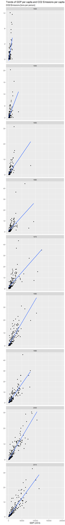

```r
# Filter data for years between 1800-2020
recent_data <- merged_data %>%
  filter(Year %in% 1800:2020)

# NOTE: DELETE THIS WHEN DONE FIXING CODE BELOW:
# Calculate total CO2 emissions for each country for all time
total_emissions <- recent_data %>%
  group_by(country) %>%
  summarise(total_CO2_emissions = sum(CO2, na.rm = TRUE))

# NOTE: DELETE THIS WHEN DONE FIXING CODE BELOW:
# Select the top 10 countries
top_countries <- total_emissions %>%
  top_n(10, wt = total_CO2_emissions)

# Filter the original data for ALL countries
filtered_data <- merged_data %>%
  filter(country %in% recent_data$country)

# Create a new variable for decade
filtered_data_decade <- filtered_data %>%
  mutate(decade = 10 * (Year %/% 10)) %>%
  filter(decade %in% 1930:2019) %>%
  group_by(country, decade)%>%
  summarize(GDPavg=mean(GDP), CO2avg=mean(CO2))


# Create a line plot for the selected countries faceted by decade
filtered_data_decade %>%
  ggplot(aes(x = GDPavg, y = CO2avg)) +
  geom_point() +
  geom_smooth(method = "lm", se = FALSE) +
  facet_wrap(~ decade, scales = "free_y", ncol = 1) +  # Stacking each facet
  labs(title = "Trends of GDP per capita and CO2 Emissions per capita",
       x = "GDP (US $)",
       y = "",
       subtitle = "CO2 Emissions [tons per person]")
```

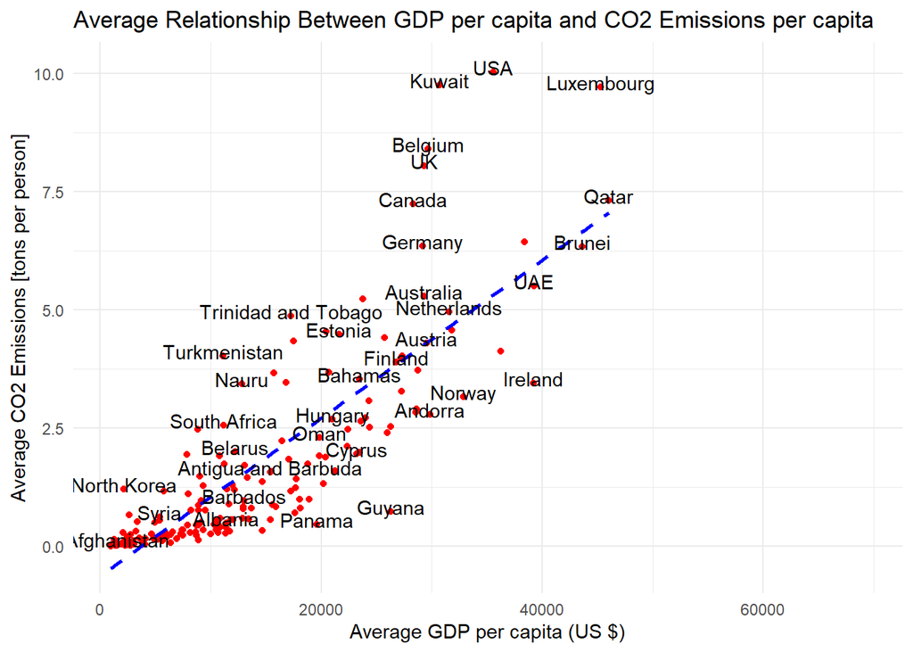

```r
#2: Visual exploring the relationship between the two quantitative variables you are investigating

# Group by country and calculate average GDP and CO2 emissions
average_data <- filtered_data %>%
  group_by(country) %>%
  summarise(avg_GDP = mean(GDP, na.rm = TRUE),
            avg_CO2_emissions = mean(CO2,
                                     na.rm = TRUE)
            )

# Create a scatter plot
average_data %>%
  ggplot(aes(x = avg_GDP,
             y = avg_CO2_emissions,
             label = country)
         ) +
  geom_point(color = "red") +
  geom_smooth(method = "lm",
              se = FALSE,
              color = "blue",
              linetype = "dashed") +  # Add linear regression line
  geom_text(nudge_x = 0.1,
            nudge_y = 0.1,
            check_overlap = TRUE) +
  labs(title = "Average Relationship Between GDP per capita and CO2 Emissions per capita",
       x = "Average GDP per capita (US $)",
       y = "Average CO2 Emissions [tons per person]") +
  theme_minimal()
```

Both evaluations visualizations exhibit a positive relationship between average GDP and average CO2 emissions. From the first visualization, there are clear differences in the “slopes” of the models in the between each decade.

**Regression Interpretation:**

```r
# Regression Data for Visual #2:

# Fit a simple linear regression model
regression_model <- lm(avg_CO2_emissions ~ avg_GDP, data = average_data)

# Display the summary of the regression model
summary(regression_model)
```

```
Call:
lm(formula = avg_CO2_emissions ~ avg_GDP, data = average_data)

Residuals:
    Min      1Q  Median      3Q     Max
-3.0172 -0.6561 -0.0731  0.3602  5.2490

Coefficients:
              Estimate Std. Error t value Pr(>|t|)
(Intercept) -6.246e-01  1.320e-01  -4.732 4.31e-06 ***
avg_GDP      1.669e-04  7.873e-06  21.195  < 2e-16 ***
---
Signif. codes:  0 '***' 0.001 '**' 0.01 '*' 0.05 '.' 0.1 ' ' 1

Residual standard error: 1.124 on 191 degrees of freedom
  (3 observations deleted due to missingness)
Multiple R-squared:  0.7017,    Adjusted R-squared:  0.7001
F-statistic: 449.2 on 1 and 191 DF,  p-value: < 2.2e-16
```

The estimated regression model between average GDP per capita and average CO2 emissions per capita is:

y^ = -0.624 + (1.669 * 10^(-4))x

We can assess how “good” of a regression model by looking much of the variability in the response values were accounted for in the regression model, specifically looking at the regression model’s fitted values. Variance in the residual values, meanwhile represent the amount of variability not accounted for in the model.

```r
variance_table <- data.frame(
  Component = c("Variance in the response values", "Variance in the fitted values",
                "Variance in the residuals"),
  Variance = c(var(regression_model$model$avg_CO2_emissions), var(regression_model$fitted.values),
               var(regression_model$residuals)))

variance_table
```

```
                        Component Variance
1 Variance in the response values 4.215913
2   Variance in the fitted values 2.958187
3       Variance in the residuals 1.257726
```

The variance of the fitted values accounts for nearly 70.1% of variance response values while the residual variance accounts for 29.8%. This signifies that that the linear regression model is a good fit for our observations, explaining that 70.1% of variability in average CO2 emissions is explained by the model (matching with the outputted R-squared value of 0.70).